# Initial Analysis

Dwipam, Neelam

## Variable description:

FID:ROW_ID

ST_CASE:CASE_ID

LATITUDE:LATITUDE (LOCATION)

LONGITUDE:LONGITUDE (LOCATION)

PERMVIT: Number of Persons in Motor Vehicles in Transport

PERSONS: Total number of fatalities

MONTH: Month of crash

DAY_WEEK: Weekday of crash

HOUR: Hour of crash

ROUTE: Route Signing  
. 1 Interstate

. 2 U.S. Highway

. 3 State Highway

. 4 County Road

. 5 Local Street – Township

. 6 Local Street – Municipality

. 7 Local Street – Frontage Road (Since 1994)

. 8 Other

. 9 Unknown

SP_JUR: (Special Jurisdiction ). identifies if the location on the traffic way where the crash occurred qualifies as a Special Jurisdiction even though it may be patrolled by state, county or local police (e.g., all State highways running through Indian reservations are under the jurisdiction of the Indian reservation).  
. 0 No Special Jurisdiction (Includes National Forests Since 2008)  
. 1 National Park Service

. 2 Military

. 3 Indian Reservation

. 4 College/University Campus

. 5 Other Federal Properties (Since 1977)

. 8 Other (Since 1976)

. 9 Unknown

HARM_EV: The first injury or damage producing event of the crash.  
. 01 Overturn

. 02 Fire/Explosion

. 03 Immersion

. 04 Gas Inhalation

. 05 Fell from Vehicle

. 06 Injured in Vehicle

. 07 Other Non-Collision

. 08 Pedestrian

. 09 Pedalcycle

. 10 Railway Train

. 11 Animal

. 12 Motor Vehicle in Transport

. 13 Motor Vehicle in Transport in Other Roadway

. 14 Parked Motor Vehicle

. 15 Other Type Non-Motorist

. 16 Other Object

. 17 Bridge or Overpass (1975-1978 Only)

. 18 Building

. 19 Culvert

. 20 Curb or Wall

. 21 Divider

. 22 Embankment

. 23 Fence

. 24 Guard Rail

. 25 Light Support

. 26 Sign Post

. 27 Tree/Shrubbery

RELJCT1: (Relation to Junction- Within Interchange Area). identifies the crash’s location with respect to presence in an interchange area.  
. 0 No

. 1 Yes

. 8 Not Reported

. 9 Unknown

RELICT2: (Relation to Junction- Specific Location). identifies the crash’s location with respect to presence in or proximity to components typically in junction or interchange areas.  
. 1 Non-Junction

. 2 Intersection

. 3 Intersection-Related

. 4 Intersection Area

. 5 Driveway, Alley, Access, etc.

. 6 Entrance/Exit Ramp (Since 1978)

. 7 Rail Grade Crossing (Since 1979)

. 8 In Crossover (Since 1980)

. 9 Unknown

TYP_INT: various intersection types on the road.  
. 1 Not an Intersection

. 2 Four-Way Intersection

. 3 T-Intersection

. 4 Y-Intersection

. 5 Traffic Circle

. 6 Roundabout

. 7 Five-Point, or More

. 8 Not Reported

. 9 Unknown

WRK_ZONE: identifies a motor vehicle traffic crash in which the first harmful event occurs within the boundaries of a work zone or on an approach to or exit from a work zone, resulting from an activity, behavior, or control related to the movement of the traffic units through the work zone.

REL_ROAD: location of the crash

LGT_COND: the hour at which the crash occurred

WEATHER: Weather conditions

FATALS: Number of Fatalities that Occurred in the Crash.

STATE: State name.

A_RU: Rural/ Urban.  
. 1: Rural

. 2: Urban.

. 3: Unknown.

A_INTER: Interstate. . 1: Interstate.

. 2: Non-Interstate.

. 3: Unknown.

A_TOD: Time of Day.  
. 1: Daytime.

. 2: Night time.

. 3: Unknown

A_DOW: Day of week. 1: Weekday. 2: Weekend. 3: Unknown

A_CT: Crash Type. 1: Single Vehicle crash. 2: Two Vehicle Crash. 3: More than two vehicle crash

A_MC: Accident Involving a Motorcycle. 1: Motorcycle Involved Crash. 2: Other Crash

A_SPCRA: Accident involving High Speed. 1: Speeding Involved Crash. 2: Other Crash. 3: Unknown

A_PED: Accident involving a Pedestrian. 1: Yes. 2: Other crash

A_ROLL: Accident involving a rollover. 1: Yes. 2: Other crash

A_POLPUR: Accident involving a polis pursuit. 1: Yes. 2: Other crash

A_POSBAC: Driver whose Blood Alcoholic test was positive or not. 1: Positive BAC test. 2: Zero BAC test. 3: Unknown

A_D15_20: If the driver was in the age group 15-20. 1: if driver Is young in age group 15-20. 2: other crash

A_D65PLS: If the driver was olg , Age 65+. 1: if driver Is old having age around 65+. 2: other crash

A_D21_24: If the driver was in the age group 21-24. 1: if driver Is young in age group 21-24. 2: other crash

A_HR: If the accident was hit and run. 1: Yes. 2: No

A_DIST: If the driver was distracted. 1: if driver Is distracted. 2: other crash

A_DROWSY: If the driver Is drowsy or not. 1: if driver Is drowsy. 2: if driver is not drowsy

```r
library(dplyr)
county = read.csv('us_county.csv') #Received from prof. D Ficklin from geology department
fatalities = read.csv('final_data.csv')
county = county %>% select(STATE_NAME,STATE_FIPS)
county = county[!duplicated(county$STATE_NAME),]
fatalities = merge(fatalities,county,by.x = "OBJECT_ID",by.y = "STATE_FIPS",all.x =FALSE)
```

## Exploratory Data Analysis:

Now we have the data in the desired form with the State_name and their associated values. Lets do some exploratory data analysis:

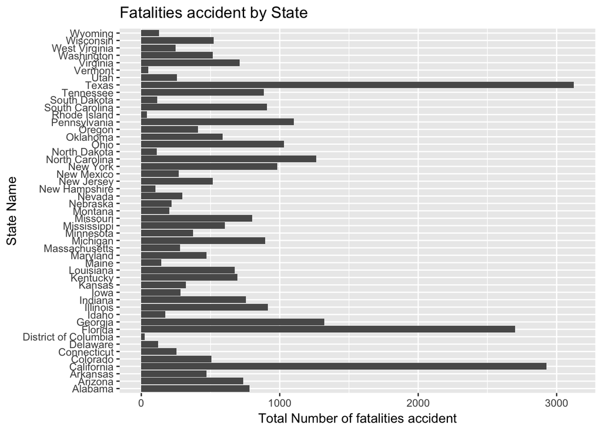

```r
library(ggplot2)
ggplot(fatalities) + aes(x = STATE_NAME) + geom_bar(stat = 'count') + coord_flip() + ylab("Total Number of fatalities accident") + xlab("State Name") + ggtitle("Fatalities accident by State")
```